**Berlin**  
Bericht 18/19

[figure not shown]

### Präambel

Dieser Bericht analysiert Veränderungen in den Neueinstellungen und den Preisen von AirBnB Objekten in Berlin, Deutschland. Er wurde zum Zwecke der Übung auf Basis öffentlich verfügbarer Daten[^1] erstellt und repräsentiert einzig die Position der Autoren. Es besteht keine Beziehung zu AirBnB.

### Neueinstellungen

#### Entwicklung

Seit 02.01.2018 wurden in Berlin 5007 AirBnB Wohnungen eingestellt. Von diesen Wohnungen weisen aktuell 73% Verfügbarkeiten von durchschnittlich 47.5 Tagen für die nächsten 3 Monate auf.

**Einstellungen von AirBnB Wohnungen haben im letzten Jahr stark zugenommen. Im Jahr 2019 wurden insgesamt 3274 neue Wohnungen eingestellt, wohingegend im Jahr 2018 nur 1733 Wohnungen eingestellt wurden. Dies entspricht einem Zuwachs von 89%.**

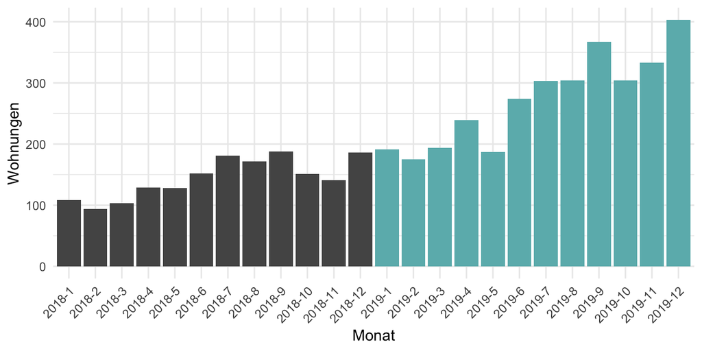

Figure 1. Neueinstellungen pro Monat.

#### Stadtteile

Neueinstellungen fallen nach wie vor sehr unterschiedlich in den Bezirken aus. Die meisten Neueinstellungen im Jahr 2019 gab es in Friedrichshain-Kreuzberg, die wenigsten in Marzahn - Hellersdorf.

**Die grössten Veränderungen gab es in Marzahn - Hellersdorf und Treptow - Köpenick. In Marzahn - Hellersdorf schrumpften die Neueinstellungen um -13.3%, in Treptow - Köpenick wuchsen die Neueinstellungen um 137.8%.**

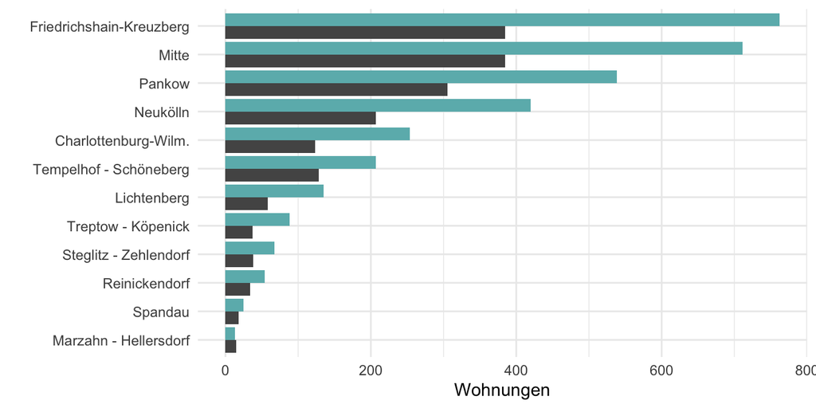

Figure 2. Neueinstellungen pro Bezirk

### Preis

Der durchschnittliche Preis der Neueinstellungen beträgt 80.8 €. Im Vergleich zum Vorjahr sind die Preise der Neueinstellungen um 1.7% gestiegen.

#### Der Einfluss der Ausstattung

Das Ausstattungsmerkmal mit dem grössten Unterschied im Preis ist Check_in_24h (72.9), das Ausstattungsmerkmal mit dem kleinsten Unterschied im Preis ist Küche (-88.9).

**Der stark negative Effekt der Küche überrascht. Er könnte durch die Art der Unterkunft moderiert werden, gegeben dass auch Hotels im Angebot enthalten sind.**

Tabelle 1. Austtatung und Einfluss auf den Preis

|  | Preis Nicht-vorh. | Preis vorh. | Differenz | Prozent vorh. |
| --- | --- | --- | --- | --- |
| Check_in_24h | 79.9 | 152.8 | 72.9 | 1.3 |
| TV | 62.5 | 100.6 | 38.2 | 48.2 |
| Wifi | 56.3 | 81.7 | 25.3 | 96.7 |
| Terrasse_Balkon | 76.1 | 92.9 | 16.8 | 28 |
| Geschirrspüler | 78.5 | 85 | 6.5 | 36.3 |
| Kaffeemaschine | 80.5 | 81.2 | 0.7 | 50.5 |
| Küche | 162.3 | 73.4 | -88.9 | 91.7 |

#### Regressionsmodell

Die Regression legt nahe, dass Küche, TV und Terrasse oder Balkon den grössten Einfluss auf den Preis in den letzten beiden Jahren hatten.

Der Einfluss der Küche ist gegenüber dem Unterschied in Tabelle 1 gesunken, jedoch nach wie vor signifikant.

**Überraschenderweise ist der Effekt eines 24h Check-ins, deskriptiv der grösste Effekt, nicht signifikant. Dies ist ebenfalls auf den Zusammenhang zur Unterkunftsart zurückzuführen.**

Es besteht ein substantieller Unterschied im Preis zwischen Unterkunftsarten. Hotels haben eine um 437.3€ höheren Preis als Unterkünfte die keine Hotels sind.

**Der Anteil von Hotels ist von 1.1% im Jahre 2018 auf 1.4% im Jahre 2019 gestiegen. Es liegt nahe, dass der Anstieg im Anteil der Hotels, den Anstieg der Objektpreise verursacht hat.**

Table 2. Regression des Preises auf die Ausstattung.

|  | Preis |  |  |
| --- | --- | --- | --- |
| Predictors | Estimates | CI | p |
| Achsenabschnitt | 90.08 | 68.95 – 111.21 | **<0.001** |
| Hotel | 437.34 | 384.88 – 489.79 | **<0.001** |
| Küche | -37.95 | -59.50 – -16.40 | **0.001** |
| TV | 28.07 | 16.67 – 39.47 | **<0.001** |
| Terrasse_Balkon | 20.71 | 8.06 – 33.35 | **0.001** |
| Check_in_24h | 42.11 | -7.81 – 92.02 | 0.098 |
| Observations | 5007 |  |  |
| R<sup>2</sup> / R<sup>2</sup> adjusted | 0.074 / 0.073 |  |  |

[^1]: Daten wurde heruntergeladen von [insideairbnb.com](http://insideairbnb.com/get-the-data.html).